# A Covid-19 no Brasil em números

Thiago Valentim

2020-04-11

### Para início de conversa

Atualmente o mundo vive em uma situação que jamais pensei que iríamos passar. Escolas e universidades com aulas suspensas, empresas de portas fechadas, competições esportivas suspensas, o que incluiu até as olímpiadas de Tóquio que ocorreriam este ano. Enfim, desde que a Organização Mundial da Saúde (OMS) classificou a *Covid-19* (do inglês, *“Coronavirus disease”*) como pandemia, autoridades vários países vêm recomendando o isolamento social para evitar o avanço da Covid-19. O vírus já infectou mais de 1,6 milhão de pessoas e provocou cerca de 100 mil mortes em todo o mundo.

A Covid-19 foi identificada pela primeira vez em Wuhan, na província de Hubei, República Popular da China, em 1 de dezembro de 2019. O primeiro caso foi reportado em 31 de dezembro do mesmo ano e no dia 11 de março de 2020 foi classificada como pandemia pela OMS. Desde então, as secretarías nacionais de saúde começaram a quantificar os pacientes infectados, recuperados e mortos pelo novo coronavírus. Apesar dos conjuntos de dados da Covid-19 apresentarem em geral problemas de subnotificação de infectados e de mortos, tenho certeza de esta pandemia será aquela cuja sociedade terá mais informações à respeito.

O **escopo** das postagens iniciais deste blog será a realização de análises descritivas da Covid-19 nos cenários local (Rio Grande do Norte), brasileiro e internacional. Para os leitores que desejarem informações sobre modelos preditivos para dados epidemiológicos, recomendo que acessem o [aplicativo](https://andersoncso.shinyapps.io/Brasil/?fbclid=IwAR0ykIzDZ341JfolzlqEDZl-cjp4IRVKXhC5AOUk5i3-eWuSo3FyiaJyo-c) desenvolvido pelo departamento de estatística da UFMT. Todos os códigos utilizados neste post estão no [meu GitHub](https://github.com/ThiagoValentimMarques).

### Sobre os dados

As informações sobre o número de casos confirmados, óbitos e pacientes recuperados da Covid-19 em âmbito internacional estão sendo obtidas pelo [conjunto de dados](https://data.humdata.org/dataset/novel-coronavirus-2019-ncov-cases) do Johns Hopkins of Public Healt. Em âmbito nacional, essas informações (com exceção do número de pacientes recuperados) encontram-se na [plataforma](https://covid.saude.gov.br/) do Ministério da Saúde sobre o novo coronavírus.

Todas as análises estatísticas foram realizadas no **software R versão 3.5.3** com o auxílio dos seguintes pacotes:

```r
library(tidyverse)
library(lubridate)
library(brazilmaps)
library(gridExtra)
library(ggspatial)
library(ggrepel)
```

### Casos confirmados e óbitos pelo novo coronavírus

No Brasil, o primeiro caso confirmado e a primeira morte foram registrados nos dias 26 de fevereiro e 17 de março, respectivamente. Vale ressaltar que somente os pacientes que vêm procurando o hospital e apresentam alguma evidência médica para Covid-19 estão sendo testados aqui no Brasil, ou seja, os casos confirmados relatados pelo Ministério da Saúde tem problema de subnotificação. Imagino que as informações relativas aos óbitios são as que mais se aproximam do valor real. Um outro indicativo de subnotificação é a taxa de letalidade muito alta (5,4%), visto que [Wu et al. (2020)](https://www.nature.com/articles/s41591-020-0822-7) identificaram taxa de 1,4% em Wuhan, que teve testagem em massa.

O Gráfico a seguir mostra a série histórica do acumulado de casos e do número de óbitos por Covid-19 no Brasil. Nota-se que a partir do dia 18/03 o acumulado dos casos confirmados começou a “subida do morro”. Apesar das subnotificações, estes são os dados que temos. Acredito que nas próximas semanas o número de casos irá “explodir” em virtude dos testes 500 mil testes rápidos prometidos pelo Governo Federal.

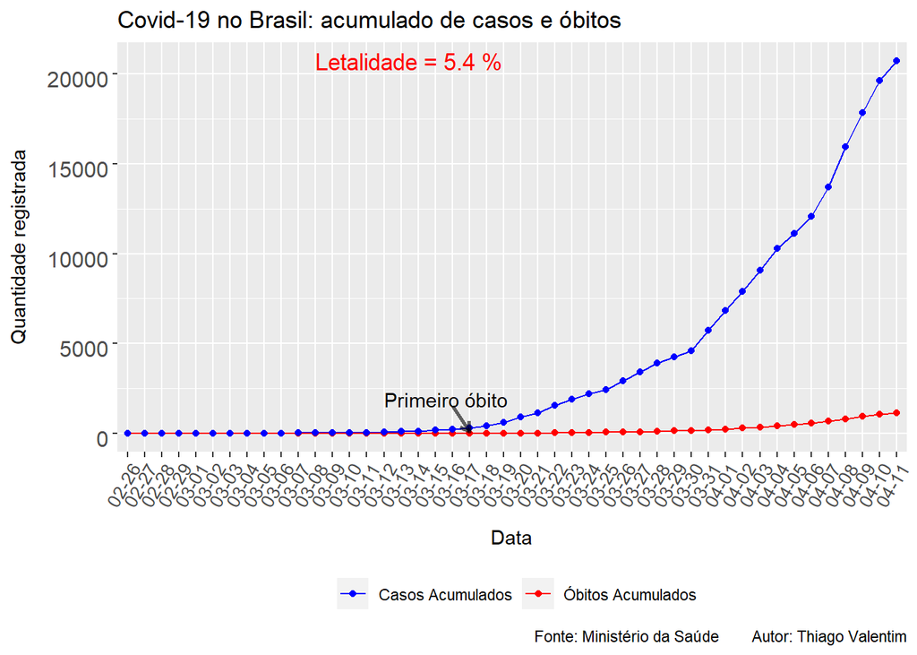

No último boletim do Ministério da Saúde, hoje 11 de abril, foram registrados 1089 casos de Covid-19, enquanto o número de óbitos foi de 68. Pelo terceiro dia consecutivo o número de casos registrados apresenta uma quantidade menor do que no dia anterior. O fato do Brasil ser um dos países com a menor quantidade de testes realizados do mundo (296 por 1 milhão de pessoas, de acordo com o [worldometer](https://www.worldometers.info/coronavirus/)) pode causar a falsa impressão de que o vírus não está se alastrando como em outros países. Desse modo, temo que algumas pessoas pensem em afrouxar o isolamento social.

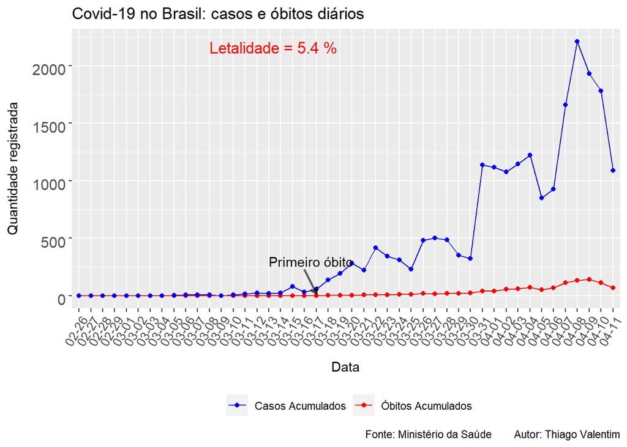

### O mapa da Covid-19 no Brasil

A seguir temos o gráfico do número de casos abslutos por estado e também um mapa com o número de casos considerando a população de cada estado. São Paulo é disparado o estado com maior número de casos no Brasil (8419) casos. Com relação a incidência do vírus, (proporção de casos numa determinada população) temos o Amazonas (25,3), Amapá (22,8), Distrito Federal (19,2), São Paulo (18,3), Ceará (17,3) e Rio de Janeiro (15,1 casos/100.000 hab.) ocupam as primeiras posições desse ranking nem um pouco orgulhoso.

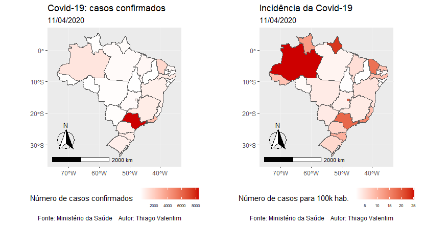

### Região Nordeste

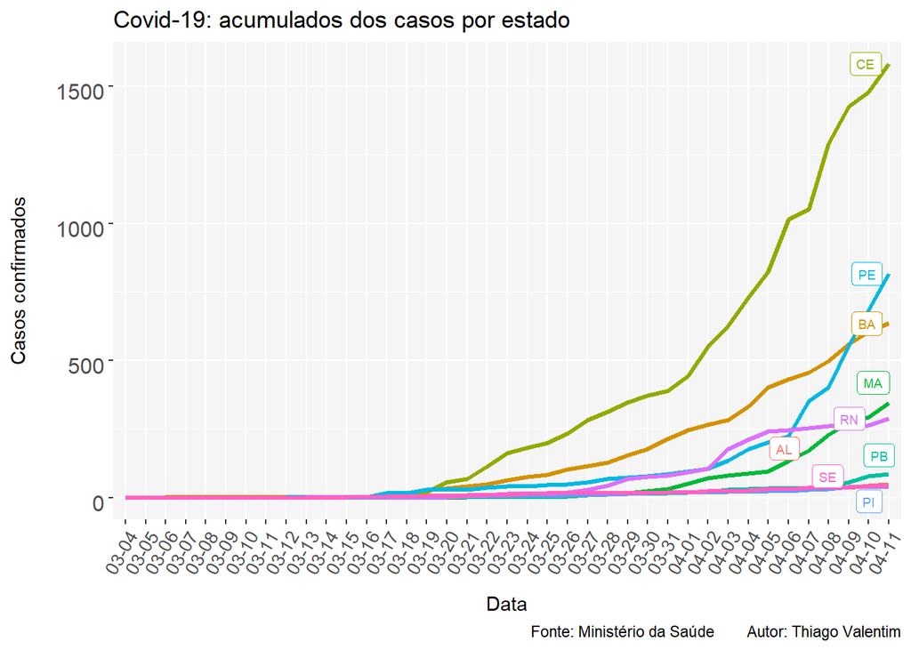

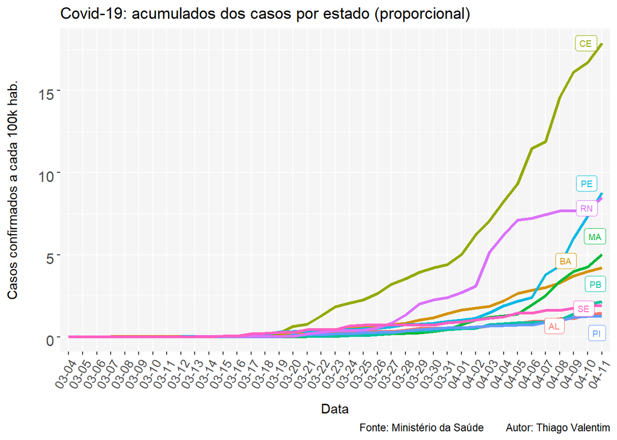

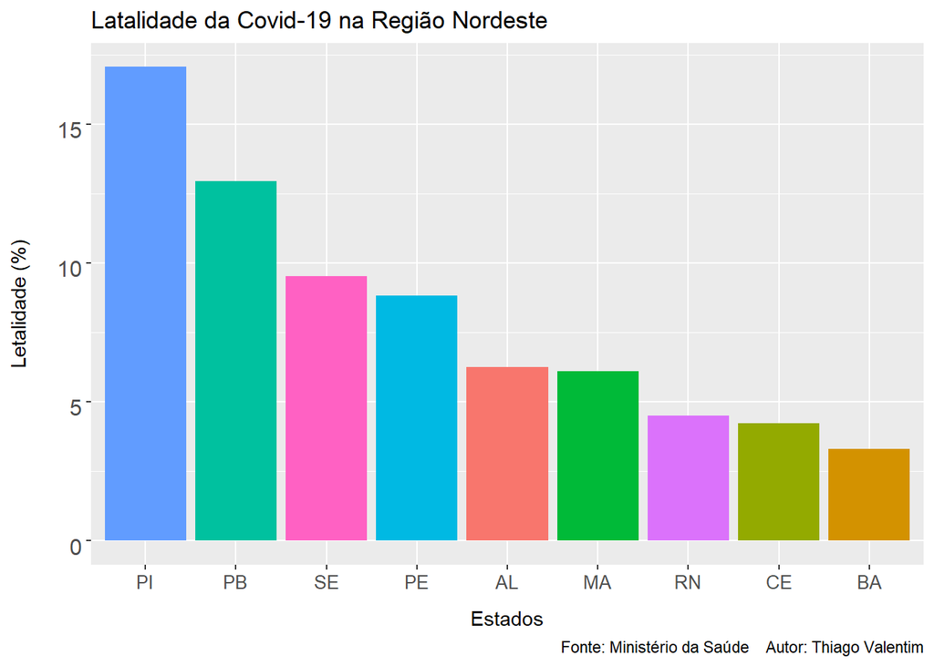

A análise de hoje se encerra por aqui. Na próxima postagem irei apresentar a evolução do acumulado de casos no Brasil comparada com o que está ocorrendo em outros países. Até a próxima pessoal!!!